# Valeur pronostique de biomarqueurs sanguins

Chaînes légères libres et mortalité, pic monoclonal et progression de la MGUS

Auteur

Guy Darcy Remesha

Date

3 novembre 2026

**NoteRésumé**

**Chaînes légères libres (FLC).** Dans la population générale de 50 ans ou plus, un doublement du FLC est associé à une hausse de 71 % du risque instantané de décès après ajustement (HR 1,71, IC à 95 % 1,58 à 1,85). Le gain de discrimination reste modeste : 0,009 sur le C de Harrell, sous le seuil de 0,01 fixé à l’avance. **Décision selon la règle prévue : réorienter.**

**Pic monoclonal.** Dans la MGUS, chaque g/dL supplémentaire multiplie par 2,50 le risque instantané de progression (IC à 95 % 1,81 à 3,46). À 20 ans, le risque de progression estimé est de 10,0 %, contre 21,0 % si l’on censure les décès. Le gain d’AUC à 10 ans est important en estimation ponctuelle, mais trop imprécis pour conclure avec 112 progressions. **Le critère de décision n’est pas rempli : il faut davantage d’événements.**

# 1 Objectif

Ce projet porte sur une question simple : un biomarqueur associé au risque est-il utile pour estimer ce risque ? L’étude distingue trois niveaux de preuve : l’association, la valeur ajoutée par rapport aux données déjà disponibles et la robustesse aux biais.

Le plan d’analyse, les biais anticipés et les critères de décision sont décrits dans le plan d’analyse statistique. Le plan a été rédigé avant tout ajustement de modèle sur les critères de jugement. Les données étant publiques et déjà publiées, il n’a pas valeur de préenregistrement. Ces analyses restent rétrospectives et ne constituent pas une validation clinique.

# 2 Partie A : FLC et mortalité

## 2.1 Population

Tableau 1: Caractéristiques selon le quartile de FLC total

|  | Ensemble | Q1 | Q2 | Q3 | Q4 |
| --- | --- | --- | --- | --- | --- |
| Effectif | 7871 | 1978 | 1962 | 1971 | 1960 |
| Âge médian (ans) | 63 | 59 | 61 | 63 | 70 |
| Femmes (%) | 55,2 | 61,0 | 57,1 | 52,3 | 50,5 |
| FLC médian (mg/dL) | 2,8 | 1,9 | 2,5 | 3,1 | 4,4 |
| Créatinine médiane (mg/dL) | 1,0 | 1,0 | 1,0 | 1,0 | 1,1 |
| Rapport κ/λ anormal (%) | 1,4 | 5,3 | 0,5 | 0,1 | 0,0 |
| MGUS (%) | 1,5 | 5,3 | 0,5 | 0,1 | 0,0 |
| Créatinine manquante (%) | 17,2 | 18,2 | 19,3 | 17,1 | 14,0 |
| Décès (%) | 27,5 | 15,7 | 18,8 | 27,5 | 48,1 |
| Suivi médian (ans) | 11,8 | 12,5 | 12,2 | 11,7 | 9,0 |

L’analyse porte sur 7 871 sujets et 2 166 décès. L’âge médian passe de 59 ans dans le premier quartile à 70 ans dans le dernier : une analyse brute serait donc fortement confondue par l’âge.

La créatinine manque pour 17,2 % des sujets. Elle manque pour 91 % des sujets prélevés en 2002-2003, contre 12 à 21 % avant. Ces derniers recrutés sont aussi plus jeunes et ont moins de décès observés. C’est la raison de l’imputation multiple et de la stratification sur la période.

**Taille d’échantillon.** Avec une corrélation entre le marqueur et les covariables (R² = 0,23), il faut 993 décès pour détecter un HR de 1,20 par doublement avec 90 % de puissance. Les 2 166 décès disponibles permettent de détecter un HR de 1,13.

## 2.2 Association

Tableau 2: HR de décès par doublement du FLC, et pour un rapport κ/λ anormal

| Modèle | HR | IC à 95 % | p |
| --- | --- | --- | --- |
| Stratifié sur la période seule | 2,74 | 2,58 à 2,91 | < 0,001 |
| Ajusté sur l’âge et le sexe | 1,80 | 1,68 à 1,93 | < 0,001 |
| Analyse principale : âge, sexe, créatinine (IM) | 1,71 | 1,58 à 1,85 | < 0,001 |
| Rapport κ/λ anormal, ajusté sur le FLC (IM) | 1,26 | 0,76 à 2,12 | 0,372 |

L’ajustement divise fortement l’effet brut : le HR passe de 2,74 à 1,71. L’âge explique l’essentiel de cette baisse. Le rapport κ/λ anormal n’apporte pas d’information mesurable une fois le FLC total pris en compte, mais seuls 114 sujets ont un rapport anormal : cet intervalle reste très large.

La relation n’est pas linéaire (p < 0,001). Le risque est plat dans les valeurs basses et augmente surtout au-dessus de la médiane (figure 1). Le HR par doublement est donc un résumé moyen.

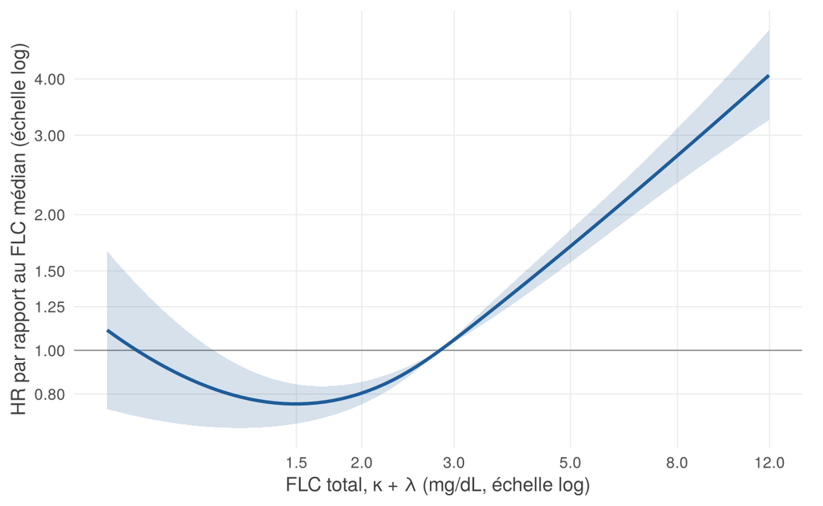

Figure 1: Relation entre le FLC et le risque de décès, ajustée (spline, cas complets). Référence : FLC médian.

L’effet diminue avec le temps (test de Schoenfeld pour le FLC : p = 0,001). Le HR passe de 2,07 dans les deux premières années à 1,51 après dix ans. Le biomarqueur reste associé au risque à long terme, mais le HR principal résume un effet qui n’est pas constant.

## 2.3 Valeur ajoutée

Tableau 3: Performances sans et avec le FLC (cas complets)

| Mesure | Base | Base + FLC |
| --- | --- | --- |
| C de Harrell, corrigé de l’optimisme | 0,790 | 0,799 |
| AUC à 5 ans | 0,802 | 0,818 |
| AUC à 10 ans | 0,822 | 0,833 |
| Brier à 5 ans | 0,092 | 0,089 |
| Brier à 10 ans | 0,131 | 0,128 |

Le modèle de base discrimine déjà bien, car l’âge porte l’essentiel du pronostic. Le FLC ajoute 0,009 sur le C (IC à 95 % 0,005 à 0,012), et 0,016 puis 0,011 sur l’AUC à 5 et 10 ans. Ce gain est réel statistiquement, mais il reste faible. Modéliser la non-linéarité le porte à 0,010 (IC à 95 % 0,007 à 0,014), légèrement au-dessus du seuil. Cette analyse exploratoire a été décidée après avoir vu les résultats : elle ne change pas le critère, mais elle confirme que le résultat est à la limite.

Pour une femme de 65 ans avec une créatinine à 1 mg/dL, le risque de décès à 10 ans est estimé à 11,6 % au 1er quartile de FLC, 16,5 % au 3e quartile et 23,2 % au 95e percentile (modèle linéaire, strate 1996). Une différence de risque visible peut donc coexister avec un faible gain de discrimination.

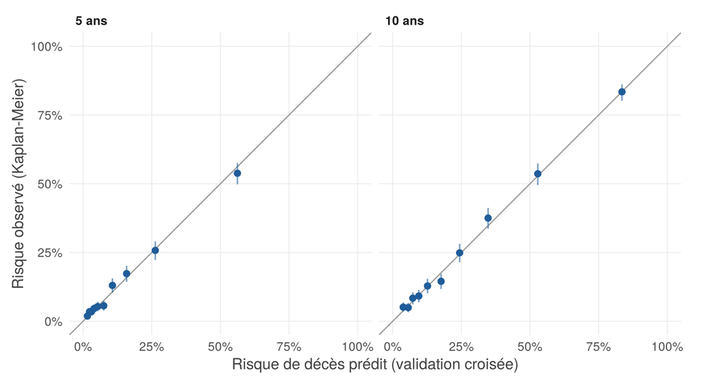

Figure 2: Calibration du modèle avec FLC, sur prédictions en validation croisée à 10 plis. Chaque point représente un décile de risque prédit.

La calibration est bonne : pente de 0,94 à 5 ans et 0,97 à 10 ans (figure 2). Le rapport observé/attendu vaut 1,01 aux deux horizons.

## 2.4 Robustesse

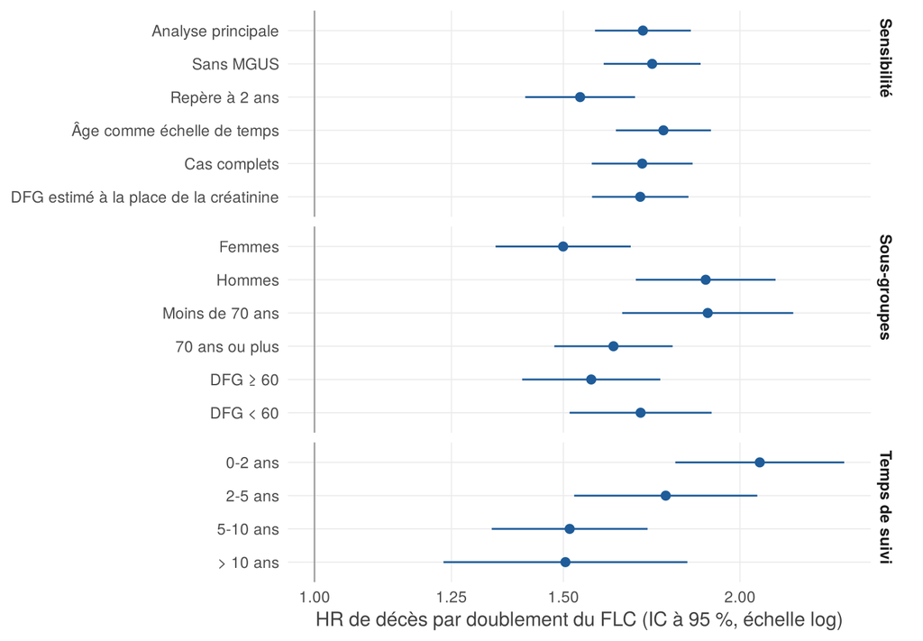

Figure 3: HR par doublement du FLC selon les analyses de sensibilité, les sous-groupes et le temps de suivi.

L’effet résiste aux cinq analyses de sensibilité (figure 3). Il diminue le plus avec l’analyse de repère à 2 ans (HR 1,54), ce qui suggère qu’une partie du signal précoce reflète une maladie déjà présente. L’E-value est de 2,25 (2,09 pour la borne basse de l’IC). Un facteur de confusion non mesuré devrait être associé au FLC et au décès avec cette force pour annuler le résultat, ce qui n’est pas invraisemblable face à l’âge biologique ou aux comorbidités.

L’association est de même ordre pour les décès circulatoires (HR 1,71), les cancers (HR 1,71) et les causes respiratoires (HR 1,49). Ce résultat exploratoire évoque un marqueur général d’état de santé plutôt qu’un marqueur spécifique d’une maladie.

**Les résultats en sous-groupes ne permettent pas de conclure.** Le test dépend de la spécification :

Tableau 4: Interactions avec le FLC : la conclusion change avec la forme du modèle (p corrigés par Holm)

| Interaction | Ajustement commun | Ajustement propre à chaque sous-groupe |
| --- | --- | --- |
| Sexe | 0,463 | 0,012 |
| Âge (< 70 / ≥ 70 ans) | 0,024 | 0,152 |
| DFG estimé (< 60 / ≥ 60) | 0,463 | 0,336 |

Pour le sexe, le test avec ajustement commun impose le même effet de la créatinine chez les hommes et les femmes. Or la créatinine n’a pas la même signification selon le sexe, car elle dépend notamment de la masse musculaire. Pour l’âge, c’est l’inverse : le signal disparaît lorsque les ajustements varient. Une hétérogénéité par sexe ou par âge reste possible, mais elle doit être testée de nouveau avant de fonder une stratégie par sous-population.

## 2.5 Comparaison à la publication d’origine

La publication d’origine compare le décile supérieur de FLC (≥ 4,72 mg/dL) au reste de la population, après exclusion des troubles plasmocytaires connus. Avec une définition proche, ce sous-échantillon public donne un HR ajusté de 2,00 (IC à 95 % 1,78 à 2,24), contre 2,1 (1,9 à 2,2) dans la publication. Les données et les exclusions diffèrent, mais l’ordre de grandeur est retrouvé.

## 2.6 Décision

Tableau 5: Application des critères fixés à l’avance

| Critère | Règle | Résultat |
| --- | --- | --- |
| C1. Association | IC à 95 % du HR excluant 1 | Rempli |
| C2. Ampleur | HR par doublement ≥ 1,20 | Rempli |
| C3. Valeur ajoutée | Gain de C ≥ 0,01 et IC excluant 0 | Non rempli |
| C4. Calibration | Pente entre 0,90 et 1,10 à 5 et 10 ans | Rempli |
| C5. Robustesse | HR ≥ 1,10 et IC excluant 1 dans toutes les sensibilités | Rempli |

**Décision : réorienter.** Le FLC est associé de façon robuste à la mortalité, mais ce travail ne démontre pas qu’il améliore suffisamment l’estimation du risque individuel dans la population générale, où l’âge domine déjà. Le gain de C est proche du seuil, et ce seuil est une convention : le résultat ne doit pas être lu comme un arrêt net. La prochaine étape serait de tester le marqueur là où l’âge discrimine moins, ou sur une décision précise, plutôt que de répéter la même étude.

# 3 Partie B : pic monoclonal et progression de la MGUS

## 3.1 Population

Tableau 6: Caractéristiques au diagnostic de MGUS

|  | Ensemble | 1,5 g/dL ou plus | Moins de 1,5 g/dL |
| --- | --- | --- | --- |
| Effectif | 1384 | 419 | 954 |
| Âge médian (ans) | 72 | 72 | 72 |
| Femmes (%) | 45,6 | 48,9 | 44,2 |
| M-spike médian (g/dL) | 1,2 | 1,7 | 0,9 |
| Hémoglobine médiane (g/dL) | 13,5 | 13,3 | 13,6 |
| Créatinine médiane (mg/dL) | 1,1 | 1,1 | 1,1 |
| Progression (%) | 8,3 | 14,3 | 5,8 |
| Décès sans progression (%) | 62,1 | 58,7 | 63,7 |

Sur 1 384 patients, on observe 115 progressions, 860 décès sans progression et 409 censures. Le décès est donc plus de sept fois plus fréquent que la progression, ce qui rend l’analyse à risques concurrents indispensable. La documentation du package évoque 1 341 patients, alors que le jeu en contient 1 384 : c’est ce dernier chiffre qui est retenu.

**Taille d’échantillon.** Le modèle complet compte 5 paramètres pour 112 progressions, soit 22,4 événements par paramètre. Les critères de Riley demandent 875 patients si le R² de Cox-Snell attendu est de 0,05, et 1 475 s’il est de 0,03. Ce dernier scénario dépasse les 1 338 patients disponibles : l’effectif est donc juste pour un modèle prédictif.

## 3.2 Pourquoi tenir compte du décès

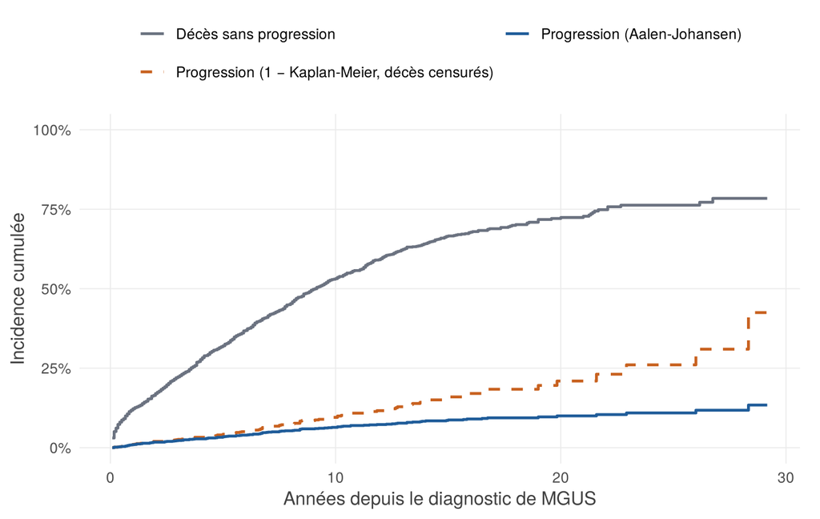

Figure 4: Incidence cumulée de la progression et du décès sans progression. La courbe en pointillés censure les décès.

Tableau 7: Risque de progression : méthode à risques concurrents et méthode naïve

| Horizon | Aalen-Johansen | IC à 95 % | 1 − Kaplan-Meier | Surestimation |
| --- | --- | --- | --- | --- |
| 5 ans | 3,4 % | 2,6 à 4,5 % | 4,2 % | × 1,2 |
| 10 ans | 6,4 % | 5,2 à 7,9 % | 9,5 % | × 1,5 |
| 20 ans | 10,0 % | 8,2 à 12,1 % | 21,0 % | × 2,1 |
| 30 ans | 13,4 % | 10,0 à 18,0 % | 42,5 % | × 3,2 |

Censurer les décès fait comme si les patients décédés pouvaient encore progresser. À 30 ans, le risque serait estimé à 42,5 % au lieu de 13,4 % (tableau 7), une erreur importante pour informer un patient ou planifier un suivi. L’estimation à 30 ans reste fragile : seuls 3 patients sont encore à risque à cet horizon. L’horizon de 20 ans (57 patients à risque) est plus fiable.

## 3.3 Effet du pic monoclonal

Tableau 8: Modèles multivariés : les deux approches répondent à deux questions différentes

| Variable | Progression (par cause) | Décès sans progression (par cause) | Progression (Fine-Gray) |
| --- | --- | --- | --- |
| Pic monoclonal, par g/dL | 2,50 (1,81 à 3,46) | 0,95 (0,84 à 1,07) | 2,50 (1,84 à 3,40) |
| Âge, par 10 ans | 1,13 (0,95 à 1,33) | 1,79 (1,67 à 1,93) | 0,84 (0,75 à 0,95) |
| Homme | 1,13 (0,74 à 1,72) | 1,51 (1,31 à 1,75) | 0,87 (0,59 à 1,30) |
| Hémoglobine, par g/dL | 0,88 (0,79 à 0,98) | 0,89 (0,86 à 0,92) | 0,97 (0,88 à 1,07) |
| Créatinine, par doublement | 0,82 (0,52 à 1,28) | 1,33 (1,19 à 1,48) | 0,70 (0,47 à 1,05) |

Le pic monoclonal prédit la progression et non le décès sans progression : son HR dans ce dernier modèle est de 0,95 (IC à 95 % 0,84 à 1,07). Il n’y a pas de signe de non-linéarité (p = 0,514) ni de non-proportionnalité (test global p = 0,773).

**L’âge illustre bien la différence entre les deux modèles.** Dans le modèle par cause, l’âge n’est pas significativement lié à la progression (HR 1,13, IC à 95 % 0,95 à 1,33). Dans le modèle de Fine-Gray, il la réduit (HR 0,84). L’âge ne protège pas biologiquement : les patients âgés meurent plus souvent avant de progresser, donc ils cumulent moins de progressions. Le modèle par cause répond à la question du mécanisme, celui de Fine-Gray à celle du risque absolu.

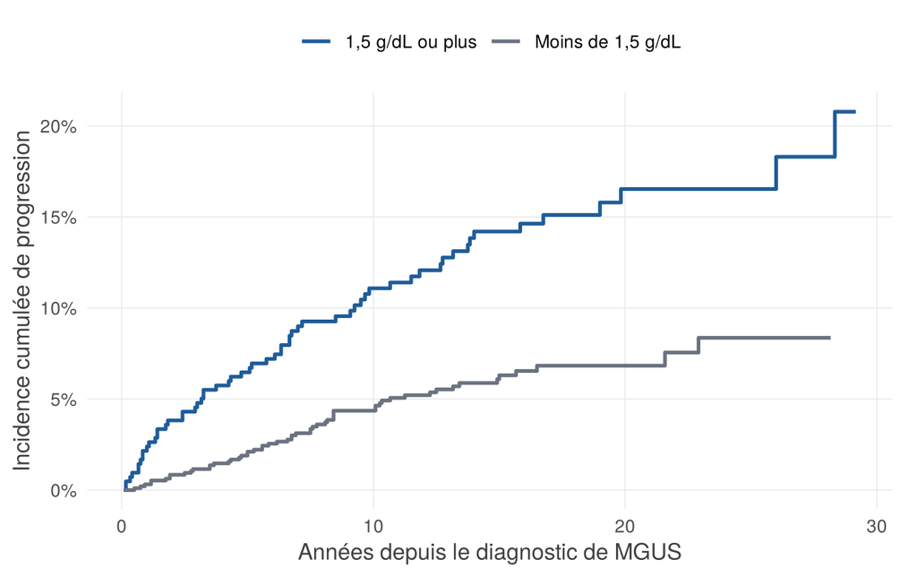

Figure 5: Incidence cumulée de progression selon le pic monoclonal.

À 20 ans, le risque de progression est de 16,5 % avec un pic d’au moins 1,5 g/dL, contre 6,8 % en dessous (test de Gray p < 0,001, figure 5). Selon le modèle de Fine-Gray, une femme de 60 ans avec une hémoglobine à 13 g/dL et une créatinine à 1 mg/dL aurait un risque à 20 ans de 6,5 % pour un pic de 0,5 g/dL et de 34,2 % pour un pic de 2,5 g/dL.

Les interactions avec le sexe et l’âge ne sont pas significatives, mais ces tests manquent de puissance avec 112 progressions. L’ajustement sur l’année de diagnostic ne modifie pas l’effet (HR 2,58).

## 3.4 Valeur ajoutée et décision

Tableau 9: AUC de progression dépendante du temps, en validation croisée bootstrap (100 réplications)

| Modèle | 10 ans | 20 ans |
| --- | --- | --- |
| Âge et sexe | 0,55 (0,44 à 0,64) | 0,59 (0,50 à 0,66) |
| + pic monoclonal | 0,66 (0,57 à 0,75) | 0,67 (0,60 à 0,75) |
| + pic, Hb, créatinine | 0,66 (0,57 à 0,75) | 0,67 (0,60 à 0,75) |

Le pic monoclonal ajoute 0,12 à l’AUC à 10 ans, mais l’intervalle de cette différence est très large (-0,03 à 0,22) et comprend 0. Ajouter l’hémoglobine et la créatinine n’améliore pas la discrimination. Même avec le pic monoclonal, l’AUC reste moyenne : ce marqueur seul ne suffit pas à bien classer les patients.

**Décision : critère non rempli, à cause de l’imprécision.** Le pic monoclonal est associé à la progression, mais ces données ne suffisent pas à prouver un gain de discrimination. Il faudrait une cohorte avec davantage de progressions ou une validation externe, ainsi que l’évaluation d’autres biomarqueurs, notamment le type d’immunoglobuline et le rapport κ/λ, qui ne sont pas disponibles ici.

# 4 Limites

- **Données rétrospectives :** une association pronostique ne prouve pas de causalité et ne montre pas qu’agir sur le marqueur modifie le risque.
- **Portée :** les deux cohortes viennent du Minnesota et d’une seule institution ou d’un seul comté. Les résultats ne sont pas transposables sans validation externe.
- **Validation :** uniquement interne.
- **Dosages et époques :** les données couvrent plusieurs décennies pour la MGUS, avec des pratiques différentes. Le jeu ne permet pas d’étudier la variabilité analytique des dosages.
- **Sous-échantillon :** `flchain` contient environ la moitié de la cohorte d’origine. Ses résultats peuvent différer légèrement des publications.
- **Biomarqueur prédictif :** aucune donnée randomisée n’étant disponible, ce travail ne dit rien de la réponse à un traitement.

# 5 Déviations par rapport au plan

1. **Tests d’interaction (Partie A).** Le plan ne fixait pas la forme du test. Un écart entre les HR par sexe et le test à ajustement commun a conduit à rapporter aussi un test avec des ajustements propres à chaque sous-groupe. Les deux sont présentés, et aucun n’a été choisi selon son résultat.
2. **Mesures à 5 et 10 ans (Partie A).** La strate 2002-2003 a été retirée de l’AUC, du Brier et de la calibration, car ses 25 cas complets n’ont pas 10 ans de suivi.
3. **Gain de C avec spline (Partie A).** Analyse exploratoire ajoutée après avoir constaté la non-linéarité. Le critère C3 reste évalué sur le modèle prévu.

# Références

- Dispenzieri A, et al. Use of nonclonal serum immunoglobulin free light chains to predict overall survival in the general population. *Mayo Clin Proc.* 2012;87:517-523.
- Kyle RA, et al. Prevalence of monoclonal gammopathy of undetermined significance. *N Engl J Med.* 2006;354:1362-1369.
- Kyle RA, et al. A long-term study of prognosis in monoclonal gammopathy of undetermined significance. *N Engl J Med.* 2002;346:564-569.
- Rajkumar SV, et al. Serum free light chain ratio is an independent risk factor for progression in monoclonal gammopathy of undetermined significance. *Blood.* 2005;106:812-817.
- McShane LM, et al. Reporting recommendations for tumor marker prognostic studies (REMARK). *J Natl Cancer Inst.* 2005;97:1180-1184.
- Fine JP, Gray RJ. A proportional hazards model for the subdistribution of a competing risk. *J Am Stat Assoc.* 1999;94:496-509.
- Putter H, Fiocco M, Geskus RB. Tutorial in biostatistics: competing risks and multi-state models. *Stat Med.* 2007;26:2389-2430.
- White IR, Royston P. Imputing missing covariate values for the Cox model. *Stat Med.* 2009;28:1982-1998.
- Riley RD, et al. Calculating the sample size required for developing a clinical prediction model. *BMJ.* 2020;368:m441.
- VanderWeele TJ, Ding P. Sensitivity analysis in observational research: introducing the E-value. *Ann Intern Med.* 2017;167:268-274.
- Inker LA, et al. New creatinine- and cystatin C-based equations to estimate GFR without race. *N Engl J Med.* 2021;385:1737-1749.

Sessions et versions des packages : voir `session_info.txt` dans le dépôt.